# Flight Performance in US

BY Abdelrahman

## Investigation Overview

This investigation delves into flight performance data to identify the root causes of flight delays and evaluate carrier performance regarding cancellations and delays.

## The Cancellation Landscape: Key Contributing Factors

Our investigation highlights carrier-related problems and adverse weather conditions as the most significant drivers of flight cancellations.

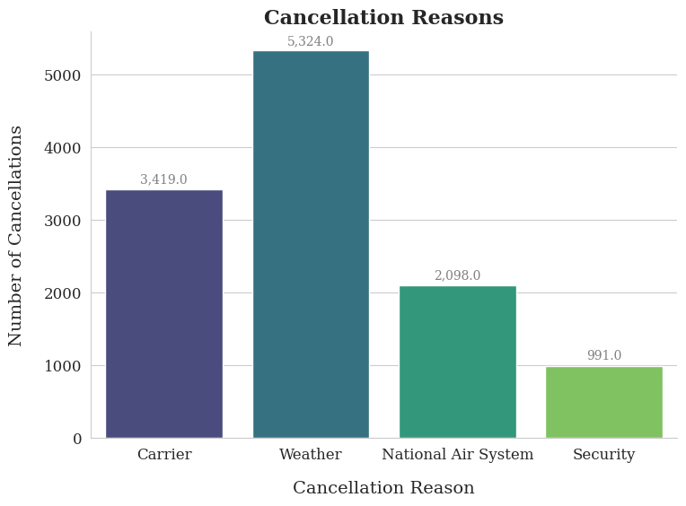

## Analysis of Carrier Cancellations: Top Performers

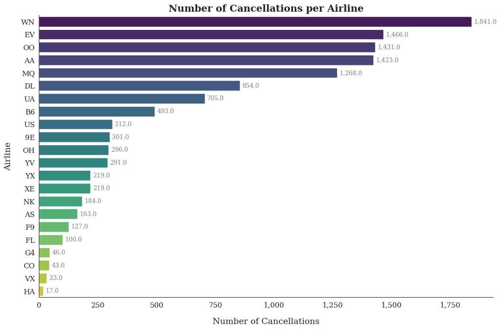

## Arrival Delays: Correlating with Cancellations?

A strong correlation appears to exist between cancellations and arrival delays. Southwest Airlines (WN), the carrier with the highest number of cancellations, also experienced the most significant total arrival delay time, followed by SkyWest Airlines (OO) and Envoy Air (EV).

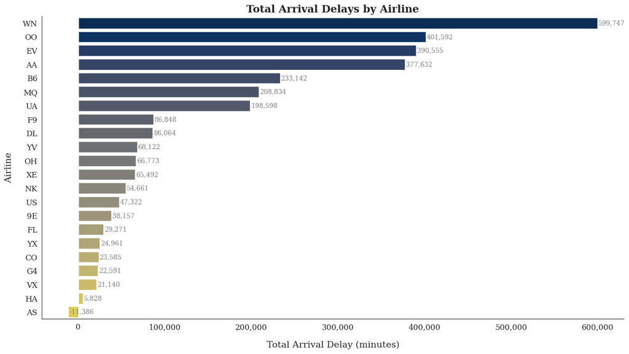

## Comparative Carrier Performance: A Decade of Delays

A comparative analysis of carrier performance over the past decade demonstrates that United Airlines (CO) and Frontier Airlines (F9) had the highest proportion of delayed flights.

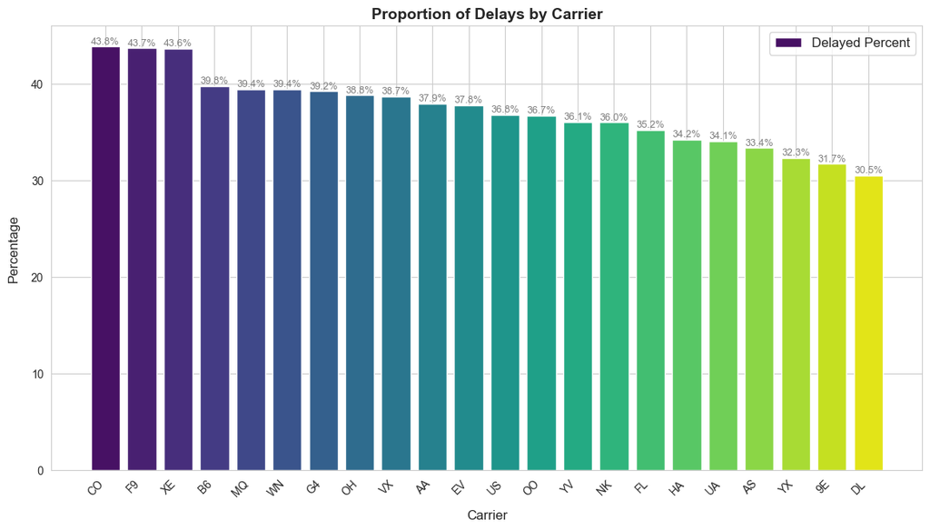

## Key Drivers of Delays: Weather and Late Aircraft

Weather and late aircraft emerged as the most significant causes of flight delays during the analyzed period. The variability in weather-related delays can be attributed to the inherent unpredictability of weather conditions.

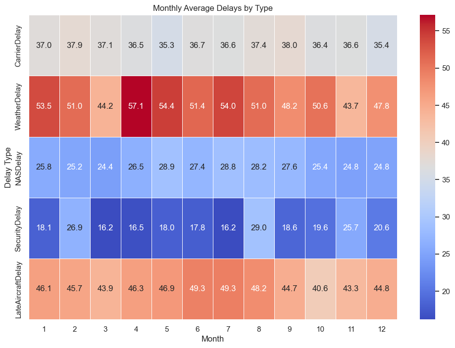

## Summary of Findings and Conclusions

This investigation yielded the following key insights:

- A significant proportion of flight cancellations were attributed to weather and aircraft-related problems.
- Southwest Airlines (WN) demonstrated the lowest performance in terms of both cancellations and arrival delays, suggesting potential areas for operational improvement.
- The analysis highlights the substantial influence of weather on flight delays, emphasizing the need for airlines to develop robust strategies for mitigating weather-related disruptions.